# Support Vector Machine

CMSC320

April 14, 2016

Support Vector Machines are state-of-the-art classification methods. It is a flexible and efficient framework to learn classifers. They build upon linear methods we have discussed previously and have a nice geometric interpretation of how they are trained (based maximum margin arguments). Their flexibility comes from the fact that they can be trained over *similarities* between observations (more on this later) rather than standard data in tabular form. This is useful in applications where string similarities, or network similarities are readily available. SVMs also follow the “classification as a space partition” framework that we have seen for logistic regression and decision trees.

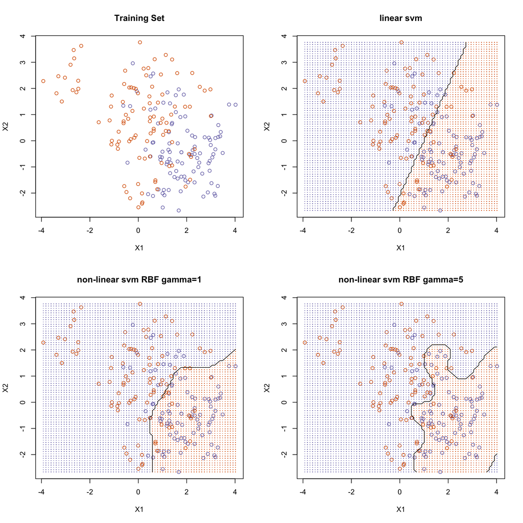

### The two-class linear Support Vector Machine

Given training data: $\{(\mathbf{x}_1,y_1), (\mathbf{x}_2,y_2),\ldots,(\mathbf{x}_n,y_n)\}$, where $\mathbf{x}_i$ is a vector of $p$ predictor values for $i$th observation, and $y_i$ is the class label (we’re going to use +1 and -1), SVMs define a *discriminative* function such that

$$\beta_0 + \beta_1 x_{i1} + \beta_2 x_{i2} + \cdots + \beta_p x_{ip} > 0 \, \mathrm{ if } y_i = 1$$

and

$$\beta_0 + \beta_1 x_{i1} + \beta_2 x_{i2} + \cdots + \beta_p x_{ip} < 0 \, \mathrm{ if } y_i = -1$$

Note that points where the *discriminative* function equals 0 form a *hyper-plane* (i.e., a line in 2D)

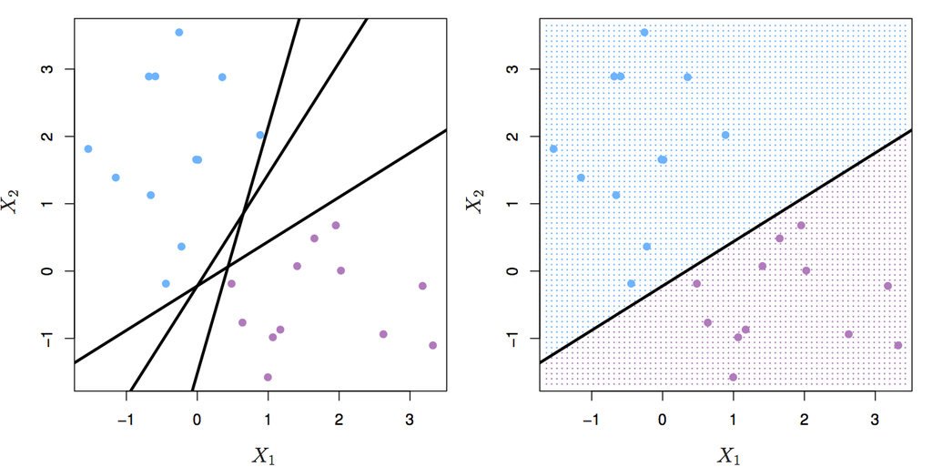

A central concept in SVMs that we did not see in logistic regression is **the margin**: the distance between the separating plane and its nearest datapoints.

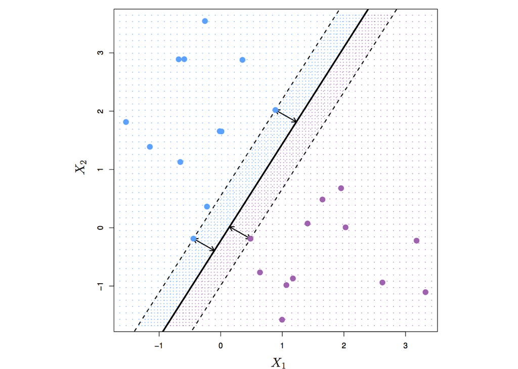

The SVMs is built from tree *key insights*:

1. **Look for the maximum margin hyper-plane**
2. Only depends on a subset of observations (support vectors)
3. Only depends on pair-wise “similarity” functions of observations

Let’s see these in turn:

**Look for the maximum margin hyper-plane**

The goal is to find the plane (think line in 2D) that separates training data with largest margin. This will tend to *generalize* better since new observations have room to fall within margin and still be classified correctly. This can be cast as *optimization* problem (see *Numerical Methods* or *Machine Learning* class for details):

$$\mathrm{max}_{\beta_0,\beta_1,\ldots,\beta_p} M \\
\mathrm{s.t} \sum_{j=1}^p \beta_p^2 = 1 \\
y_i(\beta_0 + \beta_1 x_{i1} + \ldots + \beta_p x_{ip}) \geq M \, \forall i$$

This runs however into a complication: *What if there is no separating hyper-plane?* The solution is to penalize observations on the **wrong side of the margin**.

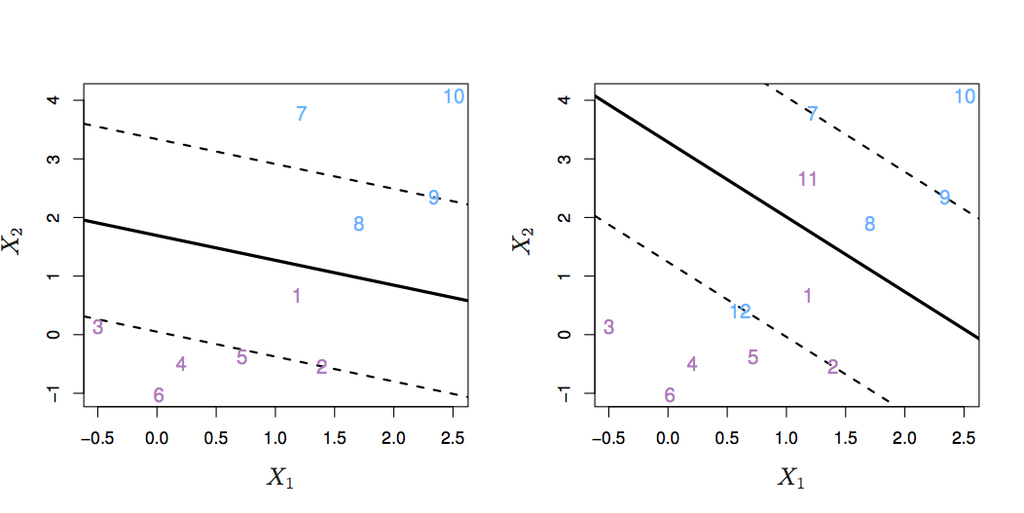

$$\mathrm{max}_{\beta_0,\beta_1,\ldots,\beta_p} M \\
\mathrm{s.t} \sum_{j=1}^p \beta_p^2 = 1 \\
y_i(\beta_0 + \beta_1 x_{i1} + \ldots + \beta_p x_{ip}) \geq M(1-\epsilon_i) \, \forall i \\
\epsilon_i \geq 0 \, \forall i \\
\sum_{i=1}^n \epsilon_i \leq C$$

$C$ is a parameter that tradeoffs the width of the margin vs. the penalty on observations on the *wrong* side of the margin. This parameter $C$ has to be selected by the user or via cross-validation model selection methods we saw before.

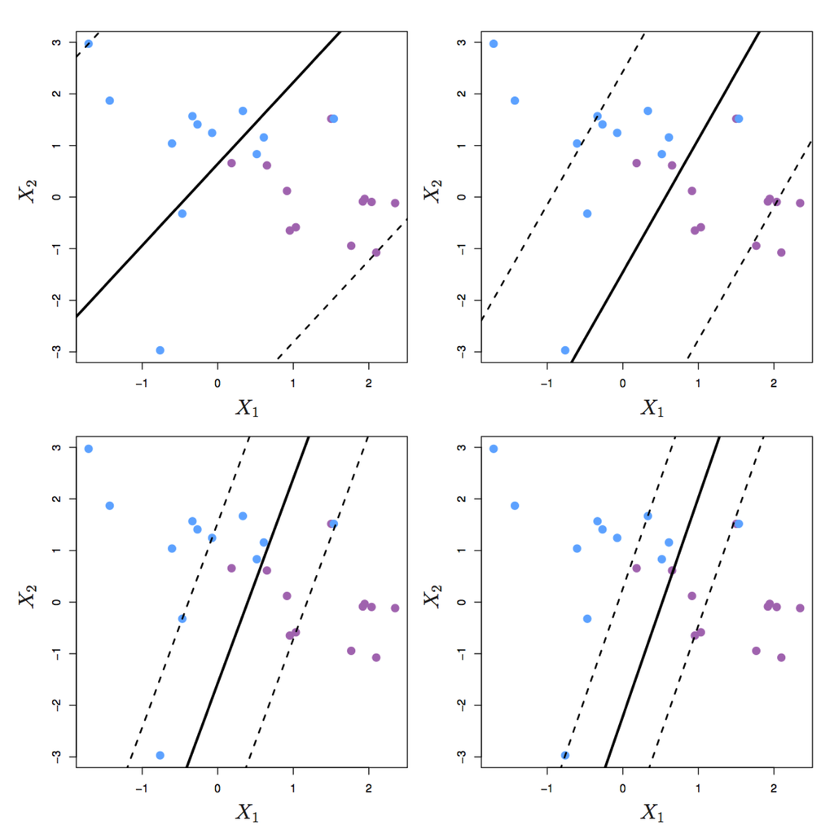

*Key insight no. 2*: **SVMs only depend on a subset of observations (support vectors)**

As a result of maximum-margin formulation, we only need observations that are on the “wrong” side of the margin to get $\beta$ values. These are called *support vectors*. In general: the smaller the parameter is $C$, the learned SVM will have fewer SVs. You can also think of the number of SVs as a rough measure of the *complexity* of the SVM obtained.

*Key insight no. 3*: **SVMs only depend on pairwise “similarity” functions of observations**

We can solve the optimization problem above only using inner products between observations (as opposed to the observations themselves)

*Inner product*: $\langle x_i, x_{i'} \rangle = \sum_{j=1}^p x_{ij}x_{i'j}$

As a result, we can write the *discriminant* function in equivalent form

$$f(x) = \beta_0 + \sum_{i=1}^n \alpha_i \langle x, x_i \rangle$$

which, by definition, has $\alpha_i > 0$ **only** for SVs

### Non-linear Support Vector Machine

This last insight is how learn non-linear discriminative functions in SVMs. We can generalize inner product using “kernel” functions that provide something like an inner product:

$$f(x) = \beta_0 + \sum_{i=1}^n \alpha_i k(x, x_i)$$

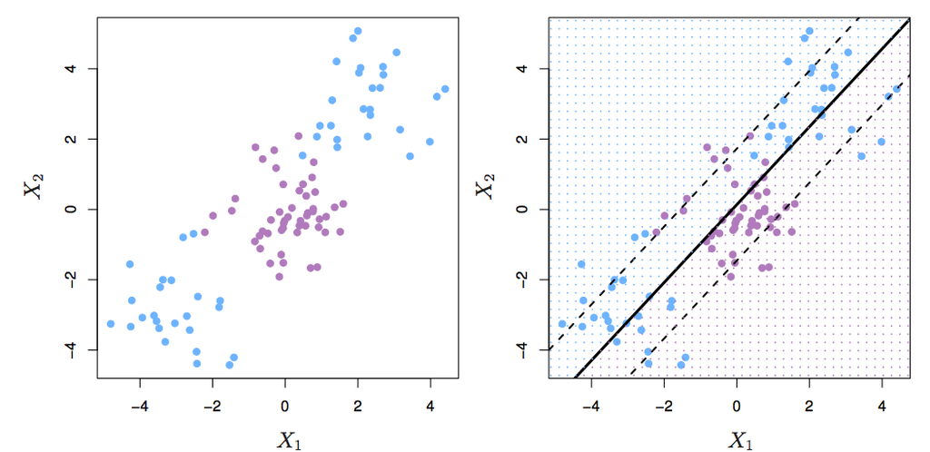

But, what is $k$? Let’s consider two examples.

- *Polynomial kernel*: $k(x,x_i) = 1+\langle x, x_i \rangle^d$
- *RBF (radial) kernel*: $k(x,x_i) = \exp\{-\gamma \sum_{j=1}^p (x_{j}-x_{ij})^2\}$

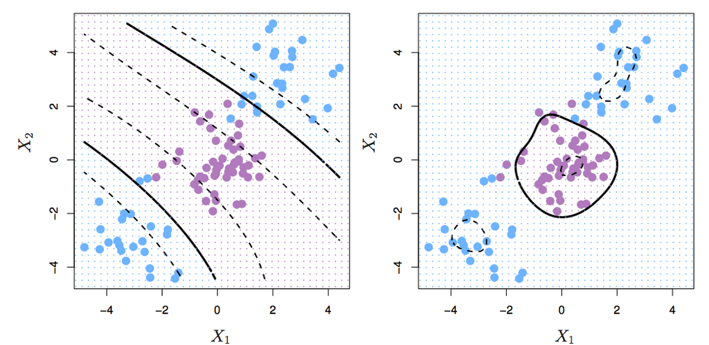

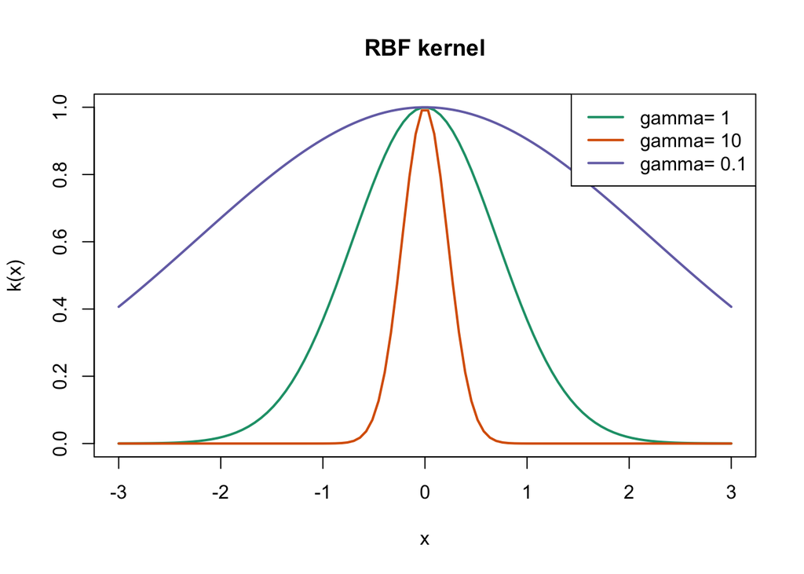

## Fitting Support Vector Machines in R

Again, the familiar *formula* interface is used to train SVMs. In this case we indicate that we are learning a *linear* SVM using the `kernel` function argument. The tradeoff parameter $C$ is indicated in the `cost` function argument. Here we are fitting three different SVMs resulting from using three different values of $C$.

```r
library(e1071)
library(ISLR)
data(Default)

n <- nrow(Default)
train_indices <- sample(n, n/2)

costs <- c(.01, 1, 100)
svm_fits <- lapply(costs, function(cost) {
  svm(default~., data=Default, cost=cost, kernel="linear",subset=train_indices)
})
```

Let’s take a look at how these SVMs behave:

```r
number_svs <- sapply(svm_fits, function(fit) fit$tot.nSV)
error_rate <- sapply(svm_fits, function(fit) {
  yhat <- predict(fit, newdata=Default[train_indices,])
  train <- mean(yhat != Default$default[train_indices])
  yhat <- predict(fit, newdata=Default[-train_indices,])
  test <- mean(yhat != Default$default[-train_indices])
  c(train=train, test=test)
})

tab <- data.frame(cost=costs, number_svs=number_svs, train_error=error_rate["train",]*100,test_error=error_rate["test",]*100)
knitr::kable(tab)
```

| cost | number_svs | train_error | test_error |
| --- | --- | --- | --- |
| 1e-02 | 352 | 3.48 | 3.18 |
| 1e+00 | 359 | 3.48 | 3.18 |
| 1e+02 | 364 | 3.48 | 3.18 |

Let’s try now a *non-linear* SVM by using a radial kernel and indicating that using the `kernel` function argument. Notice now that we have two parameters to provide to the fitting function: tradeoff parameter $C$ and parameter $\gamma$ of the radial kernel function.

```r
costs <- c(.01, 1, 10)
gamma <- c(.01, 1, 10)
parameters <- expand.grid(costs, gamma)

svm_fits <- lapply(seq(nrow(parameters)), function(i) {
  svm(default~., data=Default, cost=parameters[i,1], kernel="radial", gamma=parameters[i,2], subset=train_indices)
})
```

Let’s take at the result in this case:

```r
number_svs <- sapply(svm_fits, function(fit) fit$tot.nSV)
error_rate <- sapply(svm_fits, function(fit) {
  yhat <- predict(fit, newdata=Default[train_indices,])
  train <- mean(yhat != Default$default[train_indices])
  yhat <- predict(fit, newdata=Default[-train_indices,])
  test <- mean(yhat != Default$default[-train_indices])
  c(train=train, test=test)
})

tab <- data.frame(cost=parameters[,1], gamma=parameters[,2], number_svs=number_svs, train_error=error_rate["train",]*100,test_error=error_rate["test",]*100)
knitr::kable(tab)
```

| cost | gamma | number_svs | train_error | test_error |
| --- | --- | --- | --- | --- |
| 0.01 | 0.01 | 348 | 3.48 | 3.18 |
| 1.00 | 0.01 | 359 | 3.48 | 3.18 |
| 10.00 | 0.01 | 352 | 3.48 | 3.18 |
| 0.01 | 1.00 | 406 | 3.48 | 3.18 |
| 1.00 | 1.00 | 432 | 2.88 | 2.46 |
| 10.00 | 1.00 | 382 | 2.78 | 2.54 |
| 0.01 | 10.00 | 498 | 3.48 | 3.18 |
| 1.00 | 10.00 | 1131 | 2.62 | 2.88 |
| 10.00 | 10.00 | 944 | 2.30 | 3.10 |